# Ford Go Bike System Data

## Preliminary Wrangling

> Ford GoBike is a bike sharing service available in the San Francisco Bay area. Their service has been available in the San Francisco area since 2013, I will be exploring data about this bike sharing service from the year 2018. It is a public bike sharing system that is only available regionally.

```python
# import all packages and set plots to be embedded inline
import numpy as np
import pandas as pd
import matplotlib.pyplot as plt
import seaborn as sb

%matplotlib inline
```

```python
#loading in all 12 months of data from 2018
df01_original = pd.read_csv("201801-fordgobike-tripdata.csv");
df02_original = pd.read_csv("201802-fordgobike-tripdata.csv");
df03_original = pd.read_csv("201803-fordgobike-tripdata.csv");
df04_original = pd.read_csv("201804-fordgobike-tripdata.csv");
df05_original = pd.read_csv("201805-fordgobike-tripdata.csv");
df06_original = pd.read_csv("201806-fordgobike-tripdata.csv");
df07_original = pd.read_csv("201807-fordgobike-tripdata.csv");
df08_original = pd.read_csv("201808-fordgobike-tripdata.csv");
df09_original = pd.read_csv("201809-fordgobike-tripdata.csv");
df10_original = pd.read_csv("201810-fordgobike-tripdata.csv");
df11_original = pd.read_csv("201811-fordgobike-tripdata.csv");
df12_original = pd.read_csv("201812-fordgobike-tripdata.csv");
#making copies just incase
df01 = df01_original.copy()
df02 = df02_original.copy()
df03 = df03_original.copy()
df04 = df04_original.copy()
df05 = df05_original.copy()
df06 = df06_original.copy()
df07 = df07_original.copy()
df08 = df08_original.copy()
df09 = df09_original.copy()
df10 = df10_original.copy()
df11 = df11_original.copy()
df12 = df12_original.copy()
#looking at the data
df01.head()
```

|  | duration_sec | start_time | end_time | start_station_id | start_station_name | start_station_latitude | start_station_longitude | end_station_id | end_station_name | end_station_latitude | end_station_longitude | bike_id | user_type | member_birth_year | member_gender | bike_share_for_all_trip |
| --- | --- | --- | --- | --- | --- | --- | --- | --- | --- | --- | --- | --- | --- | --- | --- | --- |
| 0 | 75284 | 2018-01-31 22:52:35.2390 | 2018-02-01 19:47:19.8240 | 120 | Mission Dolores Park | 37.761420 | -122.426435 | 285 | Webster St at O'Farrell St | 37.783521 | -122.431158 | 2765 | Subscriber | 1986.0 | Male | No |
| 1 | 85422 | 2018-01-31 16:13:34.3510 | 2018-02-01 15:57:17.3100 | 15 | San Francisco Ferry Building (Harry Bridges Pl... | 37.795392 | -122.394203 | 15 | San Francisco Ferry Building (Harry Bridges Pl... | 37.795392 | -122.394203 | 2815 | Customer | NaN | NaN | No |
| 2 | 71576 | 2018-01-31 14:23:55.8890 | 2018-02-01 10:16:52.1160 | 304 | Jackson St at 5th St | 37.348759 | -121.894798 | 296 | 5th St at Virginia St | 37.325998 | -121.877120 | 3039 | Customer | 1996.0 | Male | No |
| 3 | 61076 | 2018-01-31 14:53:23.5620 | 2018-02-01 07:51:20.5000 | 75 | Market St at Franklin St | 37.773793 | -122.421239 | 47 | 4th St at Harrison St | 37.780955 | -122.399749 | 321 | Customer | NaN | NaN | No |
| 4 | 39966 | 2018-01-31 19:52:24.6670 | 2018-02-01 06:58:31.0530 | 74 | Laguna St at Hayes St | 37.776435 | -122.426244 | 19 | Post St at Kearny St | 37.788975 | -122.403452 | 617 | Subscriber | 1991.0 | Male | No |

### What is the structure of your dataset?

> The data has been seperated into different datasets based on month. I am curious about how some of this data changes from month to month so I have decided to load in all of the 2018 datasets. These data sets contain information on individual ride instances from their customers. This information includes time data such as duration, time, and date. It also includes start and end location data from their various stations. There is also customer information, and bike ids associated to each ride.

### What is/are the main feature(s) of interest in your dataset?

> I am interested in which stations are the most popular for starting and ending. I would like to further explore if these stations have popular start-end combination pairs. I am also interested in whether or not popular stations vary month by month. This will give me an idea about people traffic and what some popular routes for biking are. I am also interested in customer type but I am not sure how I will work that into my exploration yet.

### What features in the dataset do you think will help support your investigation into your feature(s) of interest?

> Station Names will help me distinguish individual stations from each other, and which ones show up most frequently. The start and end station columns will help me understand instances of when these individual stations were starting or ending points for bikers. The monthly seperated data will allow me to know if there is any variance in this data from month to month.

## Univariate Exploration

> Now I will try to look at counts for each station occurance. It is important to me to keep this data seperated by month so that I can see the variance over time. First, I will look at the total counts per month to see if there are dramatic differences in popularity of this bike share service from month to month.

```python
#rides per month
df_rides_per_month = pd.DataFrame(columns=["month", "ride_count", "relative_count"])

count01 = df01.count()[0]
count02 = df02.count()[0]
count03 = df03.count()[0]
count04 = df04.count()[0]
count05 = df05.count()[0]
count06 = df06.count()[0]
count07 = df07.count()[0]
count08 = df08.count()[0]
count09 = df09.count()[0]
count10 = df10.count()[0]
count11 = df11.count()[0]
count12 = df12.count()[0]
total_count = count01 + count02 + count03 + count04 + count05 + count06 + count07 + count08 + count09 + count10 + count11 + count12

df_rides_per_month = df_rides_per_month.append({"month" : "Jan.", "ride_count" : count01, "relative_count" : count01/total_count}, ignore_index=True)
df_rides_per_month = df_rides_per_month.append({"month" : "Feb.", "ride_count" : count02, "relative_count" : count02/total_count}, ignore_index=True)
df_rides_per_month = df_rides_per_month.append({"month" : "Mar.", "ride_count" : count03, "relative_count" : count03/total_count}, ignore_index=True)
df_rides_per_month = df_rides_per_month.append({"month" : "Apr.", "ride_count" : count04, "relative_count" : count04/total_count}, ignore_index=True)
df_rides_per_month = df_rides_per_month.append({"month" : "May", "ride_count" : count05, "relative_count" : count05/total_count}, ignore_index=True)
df_rides_per_month = df_rides_per_month.append({"month" : "June", "ride_count" : count06, "relative_count" : count06/total_count}, ignore_index=True)
df_rides_per_month = df_rides_per_month.append({"month" : "July", "ride_count" : count07, "relative_count" : count07/total_count}, ignore_index=True)
df_rides_per_month = df_rides_per_month.append({"month" : "Aug.", "ride_count" : count08, "relative_count" : count08/total_count}, ignore_index=True)
df_rides_per_month = df_rides_per_month.append({"month" : "Sept.", "ride_count" : count09, "relative_count" : count09/total_count}, ignore_index=True)
df_rides_per_month = df_rides_per_month.append({"month" : "Oct.", "ride_count" : count10, "relative_count" : count10/total_count}, ignore_index=True)
df_rides_per_month = df_rides_per_month.append({"month" : "Nov.", "ride_count" : count11, "relative_count" : count11/total_count}, ignore_index=True)
df_rides_per_month = df_rides_per_month.append({"month" : "Dec.", "ride_count" : count12, "relative_count" : count12/total_count}, ignore_index=True)
```

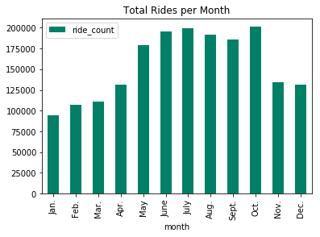

```python
#plotting the monthly data
df_rides_per_month.ride_count = df_rides_per_month.ride_count.astype(int)
df_rides_per_month.plot.bar(x='month', y='ride_count', colormap='summer', title='Total Rides per Month');
```

> The table I created and then visualized with the bar charts above show that there are some big differences in goBike use depending on the season/ month. This is good to know so that I can later acknoledge this and account for it if needed when looking at month to month comparisions of this dataset.

> Next I will look at counts for each station, I will keep this data seperated by month, as well as start vs end use, but will include total count columns in order to know which stations have the most overall use.

```python
#collecting data for starting stations
df_start_01 = df01.start_station_name.value_counts().rename_axis('station').reset_index(name='count')
df_start_02 = df02.start_station_name.value_counts().rename_axis('station').reset_index(name='count')
df_start_03 = df03.start_station_name.value_counts().rename_axis('station').reset_index(name='count')
df_start_04 = df04.start_station_name.value_counts().rename_axis('station').reset_index(name='count')
df_start_05 = df05.start_station_name.value_counts().rename_axis('station').reset_index(name='count')
df_start_06 = df06.start_station_name.value_counts().rename_axis('station').reset_index(name='count')
df_start_07 = df07.start_station_name.value_counts().rename_axis('station').reset_index(name='count')
df_start_08 = df08.start_station_name.value_counts().rename_axis('station').reset_index(name='count')
df_start_09 = df09.start_station_name.value_counts().rename_axis('station').reset_index(name='count')
df_start_10 = df10.start_station_name.value_counts().rename_axis('station').reset_index(name='count')
df_start_11 = df11.start_station_name.value_counts().rename_axis('station').reset_index(name='count')
df_start_12 = df12.start_station_name.value_counts().rename_axis('station').reset_index(name='count')
#joining the tables
df_start_count = df_start_01.join(df_start_02.set_index('station'), on='station', lsuffix='01', rsuffix='02')
df_start_count = df_start_count.join(df_start_03.set_index('station'), on='station')
df_start_count = df_start_count.join(df_start_04.set_index('station'), on='station', lsuffix='03', rsuffix='04')
df_start_count = df_start_count.join(df_start_05.set_index('station'), on='station')
df_start_count = df_start_count.join(df_start_06.set_index('station'), on='station', lsuffix='05', rsuffix='06')
df_start_count = df_start_count.join(df_start_07.set_index('station'), on='station')
df_start_count = df_start_count.join(df_start_08.set_index('station'), on='station', lsuffix='07', rsuffix='08')
df_start_count = df_start_count.join(df_start_09.set_index('station'), on='station')
df_start_count = df_start_count.join(df_start_10.set_index('station'), on='station', lsuffix='09', rsuffix='10')
df_start_count = df_start_count.join(df_start_11.set_index('station'), on='station')
df_start_count = df_start_count.join(df_start_12.set_index('station'), on='station', lsuffix='11', rsuffix='12')
#adding a total count column for all starting station occurances per station over the year
df_start_count['total'] = df_start_count.count01 + df_start_count.count02 + df_start_count.count03 + df_start_count.count04 + df_start_count.count05 + df_start_count.count06 + df_start_count.count07 + df_start_count.count08 + df_start_count.count09 + df_start_count.count10 + df_start_count.count11 + df_start_count.count12
#checking the data visually
df_start_count.head()
```

|  | station | count01 | count02 | count03 | count04 | count05 | count06 | count07 | count08 | count09 | count10 | count11 | count12 | total |
| --- | --- | --- | --- | --- | --- | --- | --- | --- | --- | --- | --- | --- | --- | --- |
| 0 | San Francisco Caltrain (Townsend St at 4th St) | 2194 | 2430.0 | 2388.0 | 2717.0 | 3220.0 | 3722.0 | 3679.0 | 3555.0 | 3032.0 | 3396.0 | 2590.0 | 2169.0 | 35092.0 |
| 1 | San Francisco Ferry Building (Harry Bridges Pl... | 2167 | 2417.0 | 2586.0 | 2739.0 | 3851.0 | 4099.0 | 4355.0 | 3900.0 | 3624.0 | 4031.0 | 2275.0 | 2417.0 | 38461.0 |
| 2 | Berry St at 4th St | 2113 | 2142.0 | 2295.0 | 2469.0 | 3236.0 | 3871.0 | 3512.0 | 3204.0 | 3026.0 | 3467.0 | 2336.0 | 2045.0 | 33716.0 |
| 3 | Market St at 10th St | 1975 | 2184.0 | 2273.0 | 2477.0 | 3154.0 | 3604.0 | 3304.0 | 3227.0 | 3245.0 | 4083.0 | 2844.0 | 2548.0 | 34918.0 |
| 4 | San Francisco Caltrain Station 2 (Townsend St... | 1890 | 1922.0 | 1943.0 | 2264.0 | 3510.0 | 3921.0 | 3849.0 | 3937.0 | 3722.0 | 4712.0 | 3143.0 | 2804.0 | 37617.0 |

```python
#collecting data for ending stations
df_end_01 = df01.end_station_name.value_counts().rename_axis('station').reset_index(name='count')
df_end_02 = df02.end_station_name.value_counts().rename_axis('station').reset_index(name='count')
df_end_03 = df03.end_station_name.value_counts().rename_axis('station').reset_index(name='count')
df_end_04 = df04.end_station_name.value_counts().rename_axis('station').reset_index(name='count')
df_end_05 = df05.end_station_name.value_counts().rename_axis('station').reset_index(name='count')
df_end_06 = df06.end_station_name.value_counts().rename_axis('station').reset_index(name='count')
df_end_07 = df07.end_station_name.value_counts().rename_axis('station').reset_index(name='count')
df_end_08 = df08.end_station_name.value_counts().rename_axis('station').reset_index(name='count')
df_end_09 = df09.end_station_name.value_counts().rename_axis('station').reset_index(name='count')
df_end_10 = df10.end_station_name.value_counts().rename_axis('station').reset_index(name='count')
df_end_11 = df11.end_station_name.value_counts().rename_axis('station').reset_index(name='count')
df_end_12 = df12.end_station_name.value_counts().rename_axis('station').reset_index(name='count')
#joing the tables
df_end_count = df_end_01.join(df_end_02.set_index('station'), on='station', lsuffix='01', rsuffix='02')
df_end_count = df_end_count.join(df_end_03.set_index('station'), on='station')
df_end_count = df_end_count.join(df_end_04.set_index('station'), on='station', lsuffix='03', rsuffix='04')
df_end_count = df_end_count.join(df_end_05.set_index('station'), on='station')
df_end_count = df_end_count.join(df_end_06.set_index('station'), on='station', lsuffix='05', rsuffix='06')
df_end_count = df_end_count.join(df_end_07.set_index('station'), on='station')
df_end_count = df_end_count.join(df_end_08.set_index('station'), on='station', lsuffix='07', rsuffix='08')
df_end_count = df_end_count.join(df_end_09.set_index('station'), on='station')
df_end_count = df_end_count.join(df_end_10.set_index('station'), on='station', lsuffix='09', rsuffix='10')
df_end_count = df_end_count.join(df_end_11.set_index('station'), on='station')
df_end_count = df_end_count.join(df_end_12.set_index('station'), on='station', lsuffix='11', rsuffix='12')
#adding a total count column for all ending station occurances per station over the year
df_end_count['total'] = df_end_count.count01 + df_end_count.count02 + df_end_count.count03 + df_end_count.count04 + df_end_count.count05 + df_end_count.count06 + df_end_count.count07 + df_end_count.count08 + df_end_count.count09 + df_end_count.count10 + df_end_count.count11 + df_end_count.count12
#checking the data visually
df_end_count.head()
```

|  | station | count01 | count02 | count03 | count04 | count05 | count06 | count07 | count08 | count09 | count10 | count11 | count12 | total |
| --- | --- | --- | --- | --- | --- | --- | --- | --- | --- | --- | --- | --- | --- | --- |
| 0 | San Francisco Caltrain (Townsend St at 4th St) | 2857 | 3164.0 | 3388.0 | 3373.0 | 4233.0 | 4338.0 | 4282.0 | 4362.0 | 3431.0 | 3856.0 | 3007.0 | 2679.0 | 42970.0 |
| 1 | San Francisco Ferry Building (Harry Bridges Pl... | 2433 | 2761.0 | 2999.0 | 3196.0 | 4426.0 | 4726.0 | 4789.0 | 4396.0 | 4158.0 | 4634.0 | 2783.0 | 2812.0 | 44113.0 |
| 2 | San Francisco Caltrain Station 2 (Townsend St... | 2395 | 2588.0 | 2652.0 | 3384.0 | 4315.0 | 5126.0 | 5175.0 | 5423.0 | 5291.0 | 6109.0 | 4188.0 | 3354.0 | 50000.0 |
| 3 | The Embarcadero at Sansome St | 2339 | 2427.0 | 2606.0 | 2786.0 | 3751.0 | 4355.0 | 4659.0 | 3929.0 | 3665.0 | 3960.0 | 2427.0 | 2318.0 | 39222.0 |
| 4 | Montgomery St BART Station (Market St at 2nd St) | 2168 | 2295.0 | 2322.0 | 2843.0 | 3818.0 | 3837.0 | 3641.0 | 3606.0 | 3212.0 | 3663.0 | 2359.0 | 2191.0 | 35955.0 |

> I am still wrangling my data for total counts per each station. Now that I have start and end station counts I will join them and add a column for total counts

```python
#joing start and end station data
df_all_count = df_start_count.join(df_end_count.set_index('station'), on='station', lsuffix='_start', rsuffix='_end')
#adding total count column
df_all_count['total'] = df_all_count.total_start + df_all_count.total_end
#checking data visually
df_all_count.head()
```

|  | station | count01_start | count02_start | count03_start | count04_start | count05_start | count06_start | count07_start | count08_start | count09_start | ... | count05_end | count06_end | count07_end | count08_end | count09_end | count10_end | count11_end | count12_end | total_end | total |
| --- | --- | --- | --- | --- | --- | --- | --- | --- | --- | --- | --- | --- | --- | --- | --- | --- | --- | --- | --- | --- | --- |
| 0 | San Francisco Caltrain (Townsend St at 4th St) | 2194 | 2430.0 | 2388.0 | 2717.0 | 3220.0 | 3722.0 | 3679.0 | 3555.0 | 3032.0 | ... | 4233.0 | 4338.0 | 4282.0 | 4362.0 | 3431.0 | 3856.0 | 3007.0 | 2679.0 | 42970.0 | 78062.0 |
| 1 | San Francisco Ferry Building (Harry Bridges Pl... | 2167 | 2417.0 | 2586.0 | 2739.0 | 3851.0 | 4099.0 | 4355.0 | 3900.0 | 3624.0 | ... | 4426.0 | 4726.0 | 4789.0 | 4396.0 | 4158.0 | 4634.0 | 2783.0 | 2812.0 | 44113.0 | 82574.0 |
| 2 | Berry St at 4th St | 2113 | 2142.0 | 2295.0 | 2469.0 | 3236.0 | 3871.0 | 3512.0 | 3204.0 | 3026.0 | ... | 3237.0 | 3654.0 | 3265.0 | 3003.0 | 2846.0 | 3450.0 | 2337.0 | 2067.0 | 32786.0 | 66502.0 |
| 3 | Market St at 10th St | 1975 | 2184.0 | 2273.0 | 2477.0 | 3154.0 | 3604.0 | 3304.0 | 3227.0 | 3245.0 | ... | 3138.0 | 3610.0 | 3297.0 | 3213.0 | 3287.0 | 4080.0 | 2885.0 | 2654.0 | 34365.0 | 69283.0 |
| 4 | San Francisco Caltrain Station 2 (Townsend St... | 1890 | 1922.0 | 1943.0 | 2264.0 | 3510.0 | 3921.0 | 3849.0 | 3937.0 | 3722.0 | ... | 4315.0 | 5126.0 | 5175.0 | 5423.0 | 5291.0 | 6109.0 | 4188.0 | 3354.0 | 50000.0 | 87617.0 |

5 rows × 28 columns

> After noticing the variance in use of the bike share from month to month, I have decided that I should work with relative values. So I will change my count values to relative values based on the total amount of uses that month.

```python
#changing counts to relative values
df_all_count.count01_start = df_all_count.count01_start/df_all_count.count01_start.sum()
df_all_count.count02_start = df_all_count.count02_start/df_all_count.count02_start.sum()
df_all_count.count03_start = df_all_count.count03_start/df_all_count.count03_start.sum()
df_all_count.count04_start = df_all_count.count04_start/df_all_count.count04_start.sum()
df_all_count.count05_start = df_all_count.count05_start/df_all_count.count05_start.sum()
df_all_count.count06_start = df_all_count.count06_start/df_all_count.count06_start.sum()
df_all_count.count07_start = df_all_count.count07_start/df_all_count.count07_start.sum()
df_all_count.count08_start = df_all_count.count08_start/df_all_count.count08_start.sum()
df_all_count.count09_start = df_all_count.count09_start/df_all_count.count09_start.sum()
df_all_count.count10_start = df_all_count.count10_start/df_all_count.count10_start.sum()
df_all_count.count11_start = df_all_count.count11_start/df_all_count.count11_start.sum()
df_all_count.count12_start = df_all_count.count12_start/df_all_count.count12_start.sum()

df_all_count.total_start = df_all_count.total_start/df_all_count.total_start.sum()

df_all_count.count01_end = df_all_count.count01_end/df_all_count.count01_end.sum()
df_all_count.count02_end = df_all_count.count02_end/df_all_count.count02_end.sum()
df_all_count.count03_end = df_all_count.count03_end/df_all_count.count03_end.sum()
df_all_count.count04_end = df_all_count.count04_end/df_all_count.count04_end.sum()
df_all_count.count05_end = df_all_count.count05_end/df_all_count.count05_end.sum()
df_all_count.count06_end = df_all_count.count06_end/df_all_count.count06_end.sum()
df_all_count.count07_end = df_all_count.count07_end/df_all_count.count07_end.sum()
df_all_count.count08_end = df_all_count.count08_end/df_all_count.count08_end.sum()
df_all_count.count09_end = df_all_count.count09_end/df_all_count.count09_end.sum()
df_all_count.count10_end = df_all_count.count10_end/df_all_count.count10_end.sum()
df_all_count.count11_end = df_all_count.count11_end/df_all_count.count11_end.sum()
df_all_count.count12_end = df_all_count.count12_end/df_all_count.count12_end.sum()

df_all_count.total_end = df_all_count.total_end/df_all_count.total_end.sum()

df_all_count.total = df_all_count.total/df_all_count.total.sum()
#chacking data visually
df_all_count.head()
```

|  | station | count01_start | count02_start | count03_start | count04_start | count05_start | count06_start | count07_start | count08_start | count09_start | ... | count05_end | count06_end | count07_end | count08_end | count09_end | count10_end | count11_end | count12_end | total_end | total |
| --- | --- | --- | --- | --- | --- | --- | --- | --- | --- | --- | --- | --- | --- | --- | --- | --- | --- | --- | --- | --- | --- |
| 0 | San Francisco Caltrain (Townsend St at 4th St) | 0.023143 | 0.022830 | 0.021831 | 0.021419 | 0.018824 | 0.020560 | 0.020568 | 0.021226 | 0.018762 | ... | 0.024706 | 0.023949 | 0.023909 | 0.026011 | 0.021159 | 0.021964 | 0.025910 | 0.023656 | 0.025760 | 0.023425 |
| 1 | San Francisco Ferry Building (Harry Bridges Pl... | 0.022858 | 0.022707 | 0.023641 | 0.021592 | 0.022513 | 0.022642 | 0.024348 | 0.023286 | 0.022425 | ... | 0.025833 | 0.026091 | 0.026740 | 0.026214 | 0.025643 | 0.026396 | 0.023980 | 0.024830 | 0.026445 | 0.024779 |
| 2 | Berry St at 4th St | 0.022289 | 0.020124 | 0.020981 | 0.019464 | 0.018918 | 0.021383 | 0.019635 | 0.019130 | 0.018725 | ... | 0.018893 | 0.020173 | 0.018230 | 0.017907 | 0.017552 | 0.019652 | 0.020137 | 0.018252 | 0.019655 | 0.019956 |
| 3 | Market St at 10th St | 0.020833 | 0.020518 | 0.020780 | 0.019527 | 0.018439 | 0.019908 | 0.018472 | 0.019268 | 0.020080 | ... | 0.018315 | 0.019930 | 0.018409 | 0.019159 | 0.020271 | 0.023240 | 0.024859 | 0.023435 | 0.020601 | 0.020791 |
| 4 | San Francisco Caltrain Station 2 (Townsend St... | 0.019936 | 0.018057 | 0.017763 | 0.017848 | 0.020520 | 0.021659 | 0.021519 | 0.023507 | 0.023031 | ... | 0.025185 | 0.028300 | 0.028895 | 0.032338 | 0.032630 | 0.034798 | 0.036086 | 0.029616 | 0.029974 | 0.026293 |

5 rows × 28 columns

> Next I want to use my data to get the most popular stations based on total uses, start uses, and end uses. I suspect I will use these values later to narrow down my stations of interest to just the most popular stations.

```python
#using the count data to get the top ten most popular stations
df_most_popular = df_all_count.sort_values(by=['total'], ascending=False).iloc[0:10]
most_popular = df_most_popular.station.unique()
#using the count data to get the top twenty most popular stations
df_most_popular_20 = df_all_count.sort_values(by=['total'], ascending=False).iloc[0:20]
most_popular_20 = df_most_popular_20.station.unique()
#using the count data to get the top ten most popular start stations
df_most_popular_start = df_all_count.sort_values(by=['total_start'], ascending=False).iloc[0:20]
most_popular_start = df_most_popular_start.station.unique()
#using the count data to get the top ten most popular end stations
df_most_popular_end = df_all_count.sort_values(by=['total_end'], ascending=False).iloc[0:20]
most_popular_end = df_most_popular_end.station.unique()
```

> Next, I would like to see a visual comparison in total use per bike station. The following chart is too large to make any specific observations, but I am able to see that some stations are wildly more popular than what I would think would be the average of the other stations.

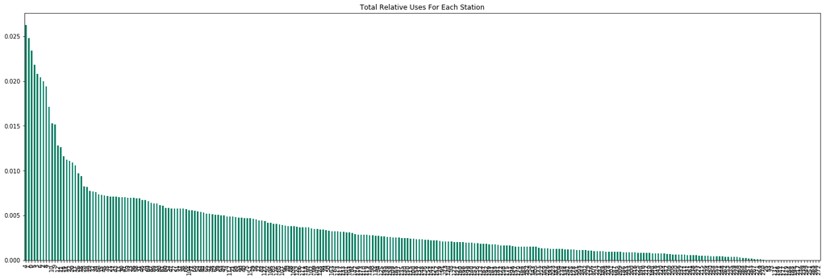

```python
df_all_count.total.sort_values(ascending=False).plot.bar(figsize=(25,8), colormap='summer', title='Total Relative Uses For Each Station');
```

### Discuss the distribution(s) of your variable(s) of interest. Were there any unusual points? Did you need to perform any transformations?

> Seeing the difference in use of the bike share service from season to season really emphasized that I will need to account for that later. Since I want to compare which stations are popular from month to month it would be better to use relative values so that the popularity of the bike share in that month does not dissort the data. I was also suprised to see that the few most used stations we're used much more than the other stations.

### Of the features you investigated, were there any unusual distributions? Did you perform any operations on the data to tidy, adjust, or change the form of the data? If so, why did you do this?

> I decided to use relative values so that when I make comparisions of station popularity from month to month the difference in overall rides for any particular month would not disort the comparison.

## Bivariate Exploration

> In this section, investigate relationships between pairs of variables in your data. Make sure the variables that you cover here have been introduced in some fashion in the previous section (univariate exploration).

> Next I would like to start encorporating other variables, first I would like to compare start station and stop station occurances. And see if there are notable differences between start station frequency and end station frequency for any particular stop.

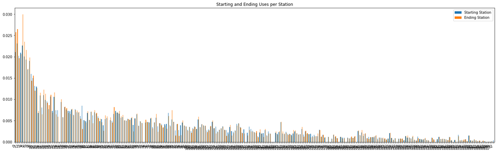

```python
pd.concat([df_all_count.total_start.rename('Starting Station'), df_all_count.total_end.rename('Ending Station')], axis=1).plot.bar(figsize=(25,8), title='Starting and Ending Uses per Station').figure.autofmt_xdate()
```

> This table is too big to make any specific observations, but I am able to confirm that some stations have large differences in how frequently they're used as starting points vs ending points. I would like to see which stations have the biggest difference.

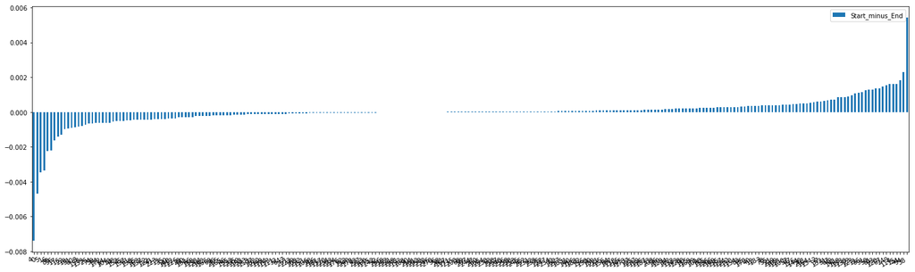

```python
#plotting difference in starting vs ending uses
df_start_end_diff = pd.DataFrame(data={'station':df_all_count.station, 'Start_minus_End':df_all_count.total_start - df_all_count.total_end})
df_start_end_diff.sort_values(by='Start_minus_End').dropna().plot.bar(figsize=(25,8)).figure.autofmt_xdate()
```

> It is interesting to see that there is such a large variance between starting use and ending use for some stations. I wonder if there is any correlation between the most popular stations and the stations that have large differences of start and stop use. It is also interesting that some stations seem to break even, I am curious if this is due to equal use for starting and stopping or if it is just a consequence of low use of the station in general.

> Next, I will make some arrays with stations of interest, these arrays will consist of stations that are more commonly start stations than stop stations, stations that are more commonly stop stations than start stations, and stations that are close to equal use as both. I will use these arrays along with my most popular stations arrays to refine my visualizations for these stations of interest.

```python
#largest difference - Most oftenly used as a stop station
df_start_end_diff.sort_values(by='Start_minus_End').head(10)
stop_stations = df_start_end_diff.sort_values(by='Start_minus_End').head(10).station.unique()
stop_stations
```

```
array(['San Francisco Caltrain Station 2  (Townsend St at 4th St)',
       'San Francisco Caltrain (Townsend St at 4th St)',
       'The Embarcadero at Sansome St',
       'San Francisco Ferry Building (Harry Bridges Plaza)',
       'Montgomery St BART Station (Market St at 2nd St)',
       'Downtown Berkeley BART', 'Folsom St at 3rd St',
       '19th Street BART Station', 'Townsend St at 7th St',
       'Civic Center/UN Plaza BART Station (Market St at McAllister St)'],
      dtype=object)
```

```python
#largest difference - Most oftenly used as a start station
df_start_end_diff.sort_values(by='Start_minus_End').dropna().tail(10)
start_stations = df_start_end_diff.sort_values(by='Start_minus_End').dropna().tail(10).station.unique()
start_stations
```

```
array(['Koshland Park', '24th St at Chattanooga St',
       'Grove St at Divisadero', 'Central Ave at Fell St',
       'Howard St at Beale St', 'Broderick St at Oak St',
       '2nd St at Folsom St', 'Lake Merritt BART Station',
       'McAllister St at Baker St', 'Bancroft Way at College Ave'],
      dtype=object)
```

```python
#lowest difference - Close to equal use
equal_stations = df_start_end_diff.query('Start_minus_End >= .001').station.unique()
equal_stations
```

```
array(['Howard St at Beale St',
       'Embarcadero BART Station (Beale St at Market St)',
       '2nd St at Folsom St', 'Central Ave at Fell St',
       'Bancroft Way at College Ave', 'Lake Merritt BART Station',
       'Page St at Scott St', 'Grove St at Divisadero',
       'Church St at Duboce Ave', 'Sanchez St at 15th St', 'Duboce Park',
       'Koshland Park', 'McAllister St at Baker St',
       'Broderick St at Oak St', '24th St at Chattanooga St',
       'Jersey St at Castro St'], dtype=object)
```

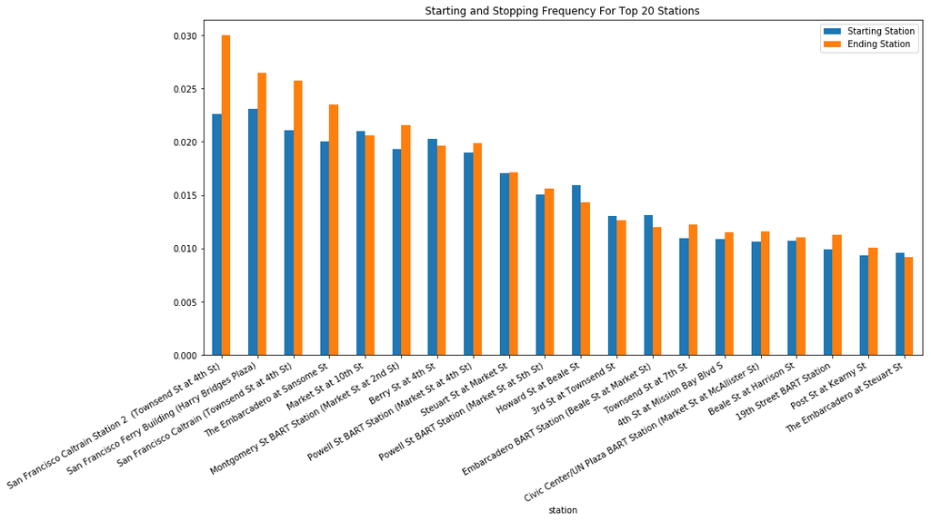

```python
#Bar chart of Start and Stop Use for 20 Most Popular Stations
df_most_popular_20 = df_most_popular_20.set_index('station')
pd.concat([df_most_popular_20.total_start.rename('Starting Station'), df_most_popular_20.total_end.rename('Ending Station')], axis=1).plot.bar(figsize=(15,8), title='Starting and Stopping Frequency For Top 20 Stations').figure.autofmt_xdate()
```

> Now, I am using those arrays to make some heat maps. I like the heatmaps for this data set because I am able to put start stations on one axis and end stations a=on another axis, while the color bar allows me to see the popularity of these pairs. One thing to be aware of at this point is that the color bar is relative to the values in the heatmap, this can be confusing when looking at the following heatmaps. For now I am only making heatmaps for January Data, df01, but plan to do heatmap subplots of all months in the next session.

```python
#Pivoting the df01 data for use as a heatmap
df01_pivot = df01.groupby(['start_station_name', 'end_station_name']).size()
df01_pivot = df01_pivot.reset_index(name = 'count')
df01_pivot = df01_pivot.pivot(index='start_station_name', columns='end_station_name', values='count')
df01_pivot = df01_pivot.fillna(0)
df01_pivot = df01_pivot[df01_pivot.columns].astype(int)
```

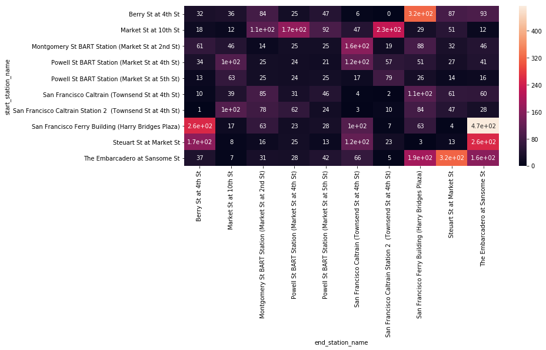

```python
#Plotting a heatmap of start and stop station pairs for the most popular stations
plt.figure(figsize=(12,5))
sb.heatmap(df01_pivot[df01_pivot.index.isin(most_popular)][most_popular].sort_index(axis=1).sort_index(), annot=True);
```

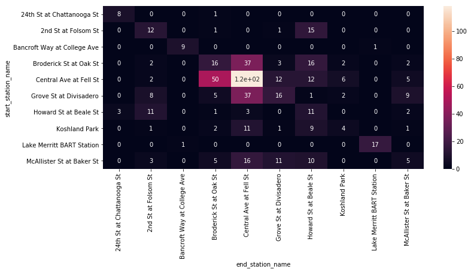

```python
#Plotting a heatmap of start and stop station pairs for the stations that are most used as start stations
plt.figure(figsize=(12,5))
sb.heatmap(df01_pivot[df01_pivot.index.isin(start_stations)][start_stations].sort_index(axis=1).sort_index(), annot=True);
```

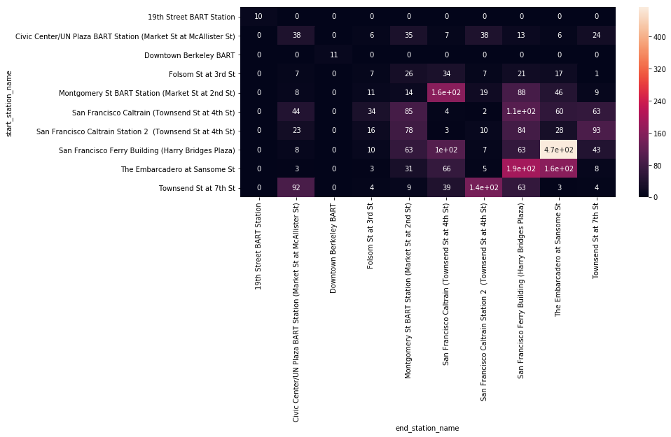

```python
#Plotting a heatmap of start and stop station pairs for the stations that are most used as end stations
plt.figure(figsize=(12,5))
sb.heatmap(df01_pivot[df01_pivot.index.isin(stop_stations)][stop_stations].sort_index(axis=1).sort_index(), annot=True);
```

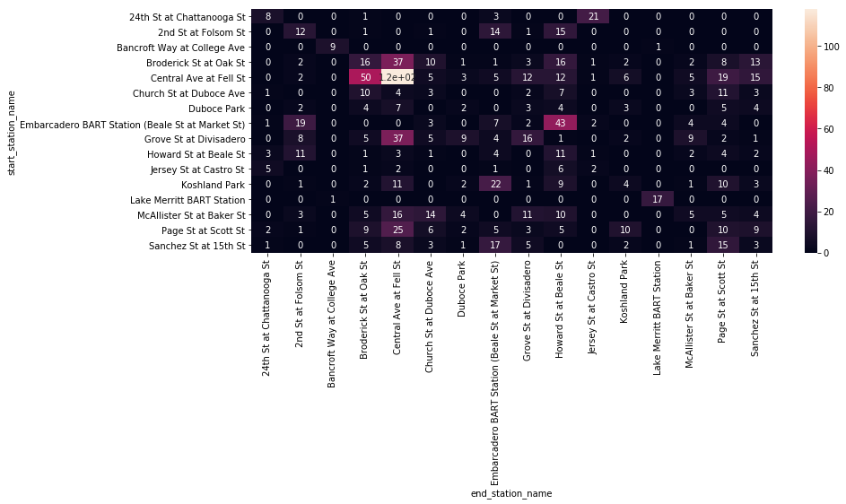

```python
#Plotting a heatmap of start and stop station pairs for the stations that have equal use as start and end stations
plt.figure(figsize=(13,5))
sb.heatmap(df01_pivot[df01_pivot.index.isin(equal_stations)][equal_stations].sort_index(axis=1).sort_index(), annot=True);
```

### Talk about some of the relationships you observed in this part of the investigation. How did the feature(s) of interest vary with other features in the dataset?

> At first I only expected to focus on the stations that had the most general use, or otherwise most popular. After looking at the large group bar chart of stop and start use for each station, I was interested in these differences between stop and start use. After plotting heatmaps I was surprised to see the variance in data between these groups of stop pairs.

### Did you observe any interesting relationships between the other features (not the main feature(s) of interest)?

> My main feature of interest was start stop station pairs and their popularity, but then I became interested in the variance of use between start and stop use cases.

## Multivariate Exploration

> One variable I haven't looked at much is the usertype, I would like to encorporate this variable into my station pair data. I hope that the transparency of the point will be a good indicator of the popularity of the station pair, while the color that sticks out the most will show whether it is most commonly used by customers or subscribers. I am also hoping to look at trends over time/ season in this part of my exploration. So first I will use subplots to look for any patterns.

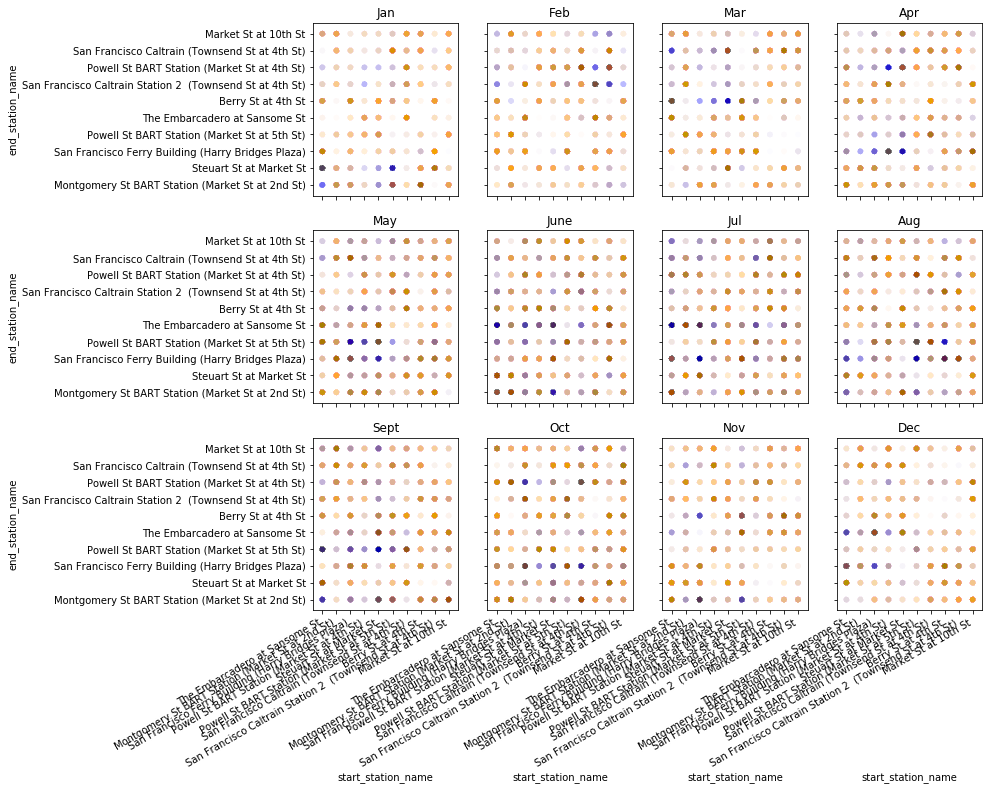

```python
f,((ax1,ax2,ax3,ax4),(ax5,ax6,ax7,ax8),(ax9,ax10,ax11,ax12)) = plt.subplots(3,4, sharex=True, sharey=True, figsize=(12,12))
ax1.set_title('Jan')
ax2.set_title('Feb')
ax3.set_title('Mar')
ax4.set_title('Apr')
ax5.set_title('May')
ax6.set_title('June')
ax7.set_title('Jul')
ax8.set_title('Aug')
ax9.set_title('Sept')
ax10.set_title('Oct')
ax11.set_title('Nov')
ax12.set_title('Dec')
sb.scatterplot(data = df01[df01.start_station_name.isin(most_popular)][df01.end_station_name.isin(most_popular)], x = df01.start_station_name, y = df01.end_station_name, alpha=1/100, hue = 'user_type', palette = {'Customer':'blue', 'Subscriber':'orange'}, legend=False, ax=ax1).figure.autofmt_xdate();
sb.scatterplot(data = df02[df02.start_station_name.isin(most_popular)][df02.end_station_name.isin(most_popular)], x = df02.start_station_name, y = df02.end_station_name, alpha=1/100, hue = 'user_type', palette = {'Customer':'blue', 'Subscriber':'orange'}, legend=False, ax=ax2).figure.autofmt_xdate();
sb.scatterplot(data = df03[df03.start_station_name.isin(most_popular)][df03.end_station_name.isin(most_popular)], x = df03.start_station_name, y = df03.end_station_name, alpha=1/100, hue = 'user_type', palette = {'Customer':'blue', 'Subscriber':'orange'}, legend=False, ax=ax3).figure.autofmt_xdate();
sb.scatterplot(data = df04[df04.start_station_name.isin(most_popular)][df04.end_station_name.isin(most_popular)], x = df04.start_station_name, y = df04.end_station_name, alpha=1/100, hue = 'user_type', palette = {'Customer':'blue', 'Subscriber':'orange'}, legend=False, ax=ax4).figure.autofmt_xdate();
sb.scatterplot(data = df05[df05.start_station_name.isin(most_popular)][df05.end_station_name.isin(most_popular)], x = df05.start_station_name, y = df05.end_station_name, alpha=1/100, hue = 'user_type', palette = {'Customer':'blue', 'Subscriber':'orange'}, legend=False, ax=ax5).figure.autofmt_xdate();
sb.scatterplot(data = df06[df06.start_station_name.isin(most_popular)][df06.end_station_name.isin(most_popular)], x = df06.start_station_name, y = df06.end_station_name, alpha=1/100, hue = 'user_type', palette = {'Customer':'blue', 'Subscriber':'orange'}, legend=False, ax=ax6).figure.autofmt_xdate();
sb.scatterplot(data = df07[df07.start_station_name.isin(most_popular)][df07.end_station_name.isin(most_popular)], x = df07.start_station_name, y = df07.end_station_name, alpha=1/100, hue = 'user_type', palette = {'Customer':'blue', 'Subscriber':'orange'}, legend=False, ax=ax7).figure.autofmt_xdate();
sb.scatterplot(data = df08[df08.start_station_name.isin(most_popular)][df08.end_station_name.isin(most_popular)], x = df08.start_station_name, y = df08.end_station_name, alpha=1/100, hue = 'user_type', palette = {'Customer':'blue', 'Subscriber':'orange'}, legend=False, ax=ax8).figure.autofmt_xdate();
sb.scatterplot(data = df09[df09.start_station_name.isin(most_popular)][df09.end_station_name.isin(most_popular)], x = df09.start_station_name, y = df09.end_station_name, alpha=1/100, hue = 'user_type', palette = {'Customer':'blue', 'Subscriber':'orange'}, legend=False, ax=ax9).figure.autofmt_xdate();
sb.scatterplot(data = df10[df10.start_station_name.isin(most_popular)][df10.end_station_name.isin(most_popular)], x = df10.start_station_name, y = df10.end_station_name, alpha=1/100, hue = 'user_type', palette = {'Customer':'blue', 'Subscriber':'orange'}, legend=False, ax=ax10).figure.autofmt_xdate();
sb.scatterplot(data = df11[df11.start_station_name.isin(most_popular)][df11.end_station_name.isin(most_popular)], x = df11.start_station_name, y = df11.end_station_name, alpha=1/100, hue = 'user_type', palette = {'Customer':'blue', 'Subscriber':'orange'}, legend=False, ax=ax11).figure.autofmt_xdate();
sb.scatterplot(data = df12[df12.start_station_name.isin(most_popular)][df12.end_station_name.isin(most_popular)], x = df12.start_station_name, y = df12.end_station_name, alpha=1/100, hue = 'user_type', palette = {'Customer':'blue', 'Subscriber':'orange'}, legend=False, ax=ax12).figure.autofmt_xdate();
#blue = customer, orange = subscriber
```

> I find it interesting the high concentrations of blue, or Customer user type, vary on the different scatter plots from month to month. I wonder if this could hint towards tourist patterns in the areas where the stops are from moth to month, given that these user types are not regular users of the bike service.

> Next, I will do a similiar subplot group but with heatmaps instead.

```python
df01_refined = df01[df01.start_station_name.isin(most_popular)]
df01_refined = df01_refined[df01_refined.end_station_name.isin(most_popular)]
df01_refined = df01_refined.groupby(['start_station_name', 'end_station_name']).size()/df01.count()[0]
df01_refined = df01_refined.reset_index(name = 'count')
df01_refined = df01_refined.pivot(index='start_station_name', columns='end_station_name', values='count')
df01_refined = df01_refined.fillna(0)

df02_refined = df02[df02.start_station_name.isin(most_popular)]
df02_refined = df02_refined[df02_refined.end_station_name.isin(most_popular)]
df02_refined = df02_refined.groupby(['start_station_name', 'end_station_name']).size()/df02.count()[0]
df02_refined = df02_refined.reset_index(name = 'count')
df02_refined = df02_refined.pivot(index='start_station_name', columns='end_station_name', values='count')
df02_refined = df02_refined.fillna(0)

df03_refined = df03[df03.start_station_name.isin(most_popular)]
df03_refined = df03_refined[df03_refined.end_station_name.isin(most_popular)]
df03_refined = df03_refined.groupby(['start_station_name', 'end_station_name']).size()/df03.count()[0]
df03_refined = df03_refined.reset_index(name = 'count')
df03_refined = df03_refined.pivot(index='start_station_name', columns='end_station_name', values='count')
df03_refined = df03_refined.fillna(0)

df04_refined = df04[df04.start_station_name.isin(most_popular)]
df04_refined = df04_refined[df04_refined.end_station_name.isin(most_popular)]
df04_refined = df04_refined.groupby(['start_station_name', 'end_station_name']).size()/df04.count()[0]
df04_refined = df04_refined.reset_index(name = 'count')
df04_refined = df04_refined.pivot(index='start_station_name', columns='end_station_name', values='count')
df04_refined = df04_refined.fillna(0)

df05_refined = df05[df05.start_station_name.isin(most_popular)]
df05_refined = df05_refined[df05_refined.end_station_name.isin(most_popular)]
df05_refined = df05_refined.groupby(['start_station_name', 'end_station_name']).size()/df05.count()[0]
df05_refined = df05_refined.reset_index(name = 'count')
df05_refined = df05_refined.pivot(index='start_station_name', columns='end_station_name', values='count')
df05_refined = df05_refined.fillna(0)

df06_refined = df06[df06.start_station_name.isin(most_popular)]
df06_refined = df06_refined[df06_refined.end_station_name.isin(most_popular)]
df06_refined = df06_refined.groupby(['start_station_name', 'end_station_name']).size()/df06.count()[0]
df06_refined = df06_refined.reset_index(name = 'count')
df06_refined = df06_refined.pivot(index='start_station_name', columns='end_station_name', values='count')
df06_refined = df06_refined.fillna(0)

df07_refined = df07[df07.start_station_name.isin(most_popular)]
df07_refined = df07_refined[df07_refined.end_station_name.isin(most_popular)]
df07_refined = df07_refined.groupby(['start_station_name', 'end_station_name']).size()/df07.count()[0]
df07_refined = df07_refined.reset_index(name = 'count')
df07_refined = df07_refined.pivot(index='start_station_name', columns='end_station_name', values='count')
df07_refined = df07_refined.fillna(0)

df08_refined = df08[df08.start_station_name.isin(most_popular)]
df08_refined = df08_refined[df08_refined.end_station_name.isin(most_popular)]
df08_refined = df08_refined.groupby(['start_station_name', 'end_station_name']).size()/df08.count()[0]
df08_refined = df08_refined.reset_index(name = 'count')
df08_refined = df08_refined.pivot(index='start_station_name', columns='end_station_name', values='count')
df08_refined = df08_refined.fillna(0)

df09_refined = df09[df09.start_station_name.isin(most_popular)]
df09_refined = df09_refined[df09_refined.end_station_name.isin(most_popular)]
df09_refined = df09_refined.groupby(['start_station_name', 'end_station_name']).size()/df09.count()[0]
df09_refined = df09_refined.reset_index(name = 'count')
df09_refined = df09_refined.pivot(index='start_station_name', columns='end_station_name', values='count')
df09_refined = df09_refined.fillna(0)

df10_refined = df10[df10.start_station_name.isin(most_popular)]
df10_refined = df10_refined[df10_refined.end_station_name.isin(most_popular)]
df10_refined = df10_refined.groupby(['start_station_name', 'end_station_name']).size()/df10.count()[0]
df10_refined = df10_refined.reset_index(name = 'count')
df10_refined = df10_refined.pivot(index='start_station_name', columns='end_station_name', values='count')
df10_refined = df10_refined.fillna(0)

df11_refined = df11[df11.start_station_name.isin(most_popular)]
df11_refined = df11_refined[df11_refined.end_station_name.isin(most_popular)]
df11_refined = df11_refined.groupby(['start_station_name', 'end_station_name']).size()/df11.count()[0]
df11_refined = df11_refined.reset_index(name = 'count')
df11_refined = df11_refined.pivot(index='start_station_name', columns='end_station_name', values='count')
df11_refined = df11_refined.fillna(0)

df12_refined = df12[df12.start_station_name.isin(most_popular)]
df12_refined = df12_refined[df12_refined.end_station_name.isin(most_popular)]
df12_refined = df12_refined.groupby(['start_station_name', 'end_station_name']).size()/df12.count()[0]
df12_refined = df12_refined.reset_index(name = 'count')
df12_refined = df12_refined.pivot(index='start_station_name', columns='end_station_name', values='count')
df12_refined = df12_refined.fillna(0)
```

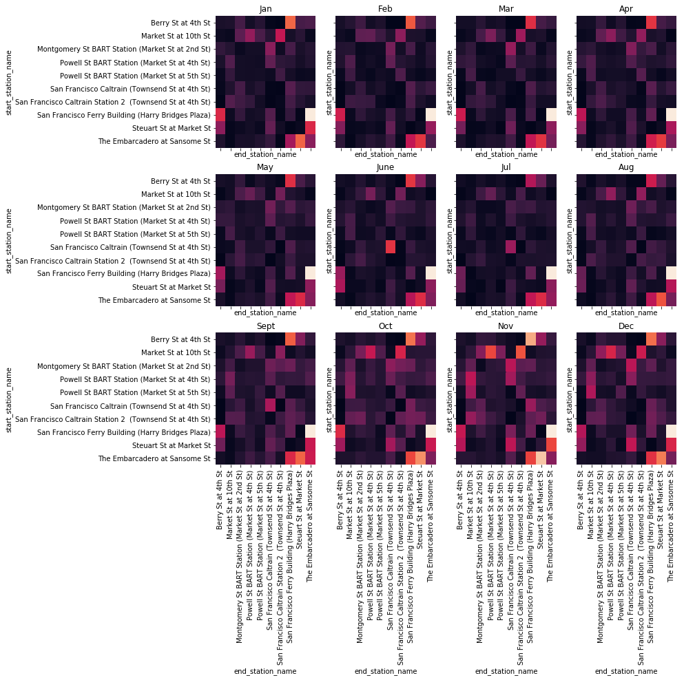

```python
f,((ax1,ax2,ax3,ax4),(ax5,ax6,ax7,ax8),(ax9,ax10,ax11,ax12)) = plt.subplots(3,4, sharex=True, sharey=True, figsize=(12,12))
ax1.set_title('Jan')
ax2.set_title('Feb')
ax3.set_title('Mar')
ax4.set_title('Apr')
ax5.set_title('May')
ax6.set_title('June')
ax7.set_title('Jul')
ax8.set_title('Aug')
ax9.set_title('Sept')
ax10.set_title('Oct')
ax11.set_title('Nov')
ax12.set_title('Dec')
sb.heatmap(df01_refined,cbar=False, ax=ax1)
sb.heatmap(df02_refined,cbar=False, ax=ax2)
sb.heatmap(df03_refined,cbar=False, ax=ax3)
sb.heatmap(df04_refined,cbar=False, ax=ax4)
sb.heatmap(df05_refined,cbar=False, ax=ax5)
sb.heatmap(df06_refined,cbar=False, ax=ax6)
sb.heatmap(df07_refined,cbar=False, ax=ax7)
sb.heatmap(df08_refined,cbar=False, ax=ax8)
sb.heatmap(df09_refined,cbar=False, ax=ax9)
sb.heatmap(df10_refined,cbar=False, ax=ax10)
sb.heatmap(df11_refined,cbar=False, ax=ax11)
sb.heatmap(df12_refined,cbar=False, ax=ax12)
#add labels and color bar
```

> I am curious as to why the Sept - Dec charts are much more colorful than the others, showing higher frequency in some station paris than the other months. Maybe these months are a popular time to bike.

### Talk about some of the relationships you observed in this part of the investigation. Were there features that strengthened each other in terms of looking at your feature(s) of interest?

> Seaon/month takes a large role in this data set. In both my last sets of sub plots you can see the visualizations get more colorful near the last 4 months (Sept - Dec). This may be a popular time for biking or for tourists or for both, given that it is often still warm enough at this time of year to be outside in San Francisco, but it is not too hot or humid to be unbareable.

### Were there any interesting or surprising interactions between features?

> At the end of your report, make sure that you export the notebook as an html file from the `File > Download as... > HTML` menu. Make sure you keep track of where the exported file goes, so you can put it in the same folder as this notebook for project submission. Also, make sure you remove all of the quote-formatted guide notes like this one before you finish your report!